# Summary Metrics for Deception Test Case

The is script is set up as a one off to determine the optimum model balancing for a given data set. You should already have prepared your data and determined number of slices before compliling this script or the outputs will not work.

In this script we compare the following method to get the best out of the data:

1. raw
2. downsample (under ratio = 0 - 100) ie. downsample_10
3. smote (over ratio = 0 - 1), i.e. smote_0.5
4. downsample and smote combination (combination of both under/over ratios) ie: ds_50_sm_0.3 (downsample to 50% and upsmote to 0.3)

This modelling used in the script is script is based on the sliced data approach.

We firstly set up the data directory for the given study area

We then prepare the data for the modelling process

We then iterate through the BGC s (this is currently a manual process). This chunck also includes the parameters to set up the balancing combination. In this case we need to adjust both the downsample and smote parameters by setting to TRUE or FALSE

- raw : downsample = FALSE, smote = FALSE
- downsampling only : downsample = TRUE, smote = FALSE
- downsample and smote : downsample = TRUE, smote = TRUE

Once all the models have been run we need to assess the optimised balancing option for the given data set. THis portion can be run using the knitr function to produce a report which highlights the best option for optimisation per variant.

```
## [1] "ESSFmc"
## # A tibble: 110 x 6
## # Groups:   balance [110]
##    balance      bal_type mu_devation mu_var mu_mean mu_sd
##    <chr>        <chr>          <dbl>  <dbl>   <dbl> <dbl>
##  1 ds_40_sm_0.7 ds_sm           218.  1048.    24.3  32.4
##  2 ds_40_sm_0.8 ds_sm           221.  1050.    24.5  32.4
##  3 ds_40_sm_0.6 ds_sm           232.  1224.    25.7  35.0
##  4 ds_40_sm_0.5 ds_sm           235.  1000.    26.2  31.6
##  5 ds_50_sm_0.8 ds_sm           240.   988.    26.7  31.4
##  6 ds_50_sm_0.7 ds_sm           245.   946.    27.2  30.8
##  7 ds_50_sm_0.9 ds_sm           249.   965.    27.6  31.1
##  8 ds_30_sm_0.7 ds_sm           249.  1061.    27.7  32.6
##  9 ds_40_sm_0.9 ds_sm           254.   970.    28.3  31.1
## 10 ds_30_sm_0.8 ds_sm           258.   990.    28.6  31.5
## # ... with 100 more rows
```

```
## [1] "SBSmc2"
## # A tibble: 102 x 6
## # Groups:   balance [102]
##    balance      bal_type mu_devation mu_var mu_mean mu_sd
##    <chr>        <chr>          <dbl>  <dbl>   <dbl> <dbl>
##  1 ds_30_sm_0.5 ds_sm           228.   949.    28.5  30.8
##  2 ds_30_sm_0.4 ds_sm           232.   989.    29.0  31.4
##  3 ds_30_sm_0.3 ds_sm           245.   912.    30.6  30.2
##  4 ds_40_sm_0.5 ds_sm           247.  1142.    30.9  33.8
##  5 ds_30_sm_0.9 ds_sm           249.   907.    31.1  30.1
##  6 ds_40_sm_0.7 ds_sm           253.  1057.    31.6  32.5
##  7 ds_30_sm_0.6 ds_sm           253.   895.    31.6  29.9
##  8 ds_30_sm_0.7 ds_sm           256.   961.    32.0  31.0
##  9 ds_40_sm_0.6 ds_sm           260.  1070.    32.5  32.7
## 10 ds_40_sm_0.3 ds_sm           263.   952.    32.8  30.9
## # ... with 92 more rows
```

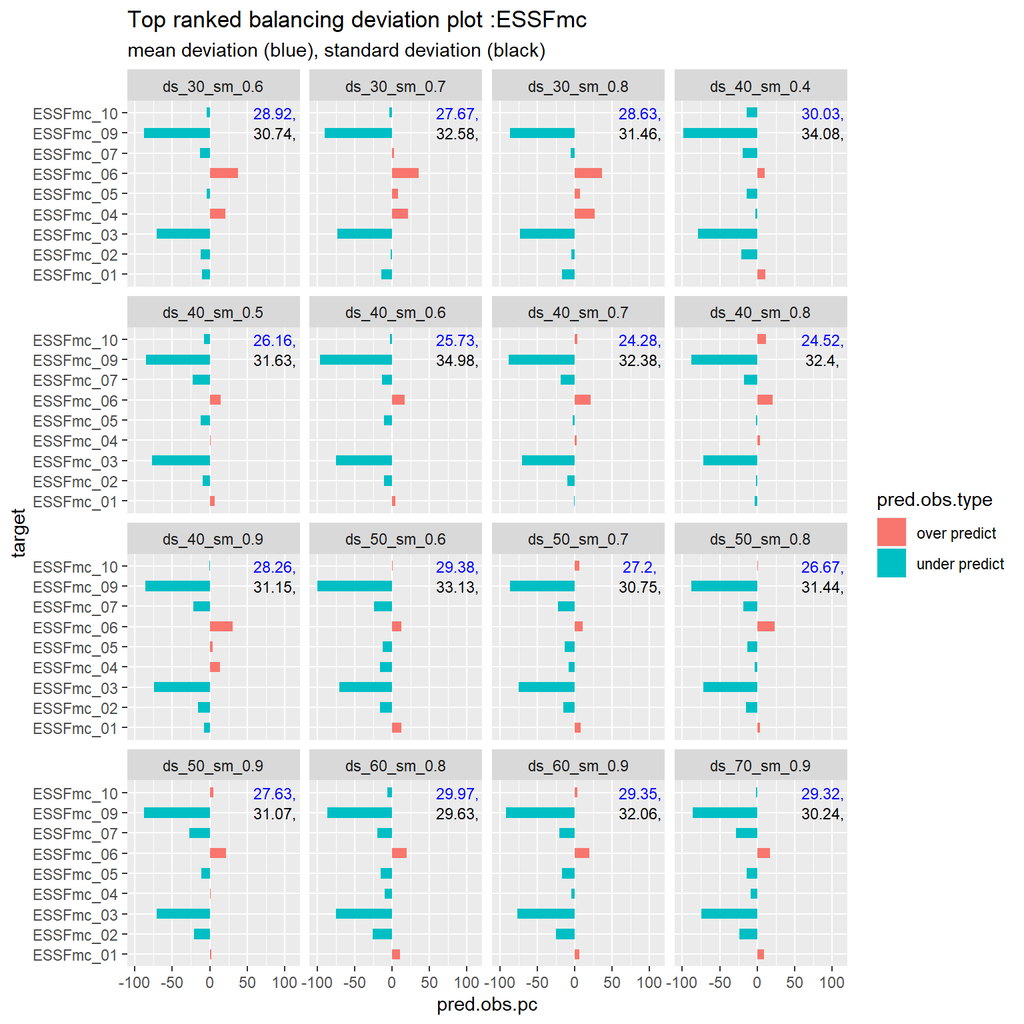

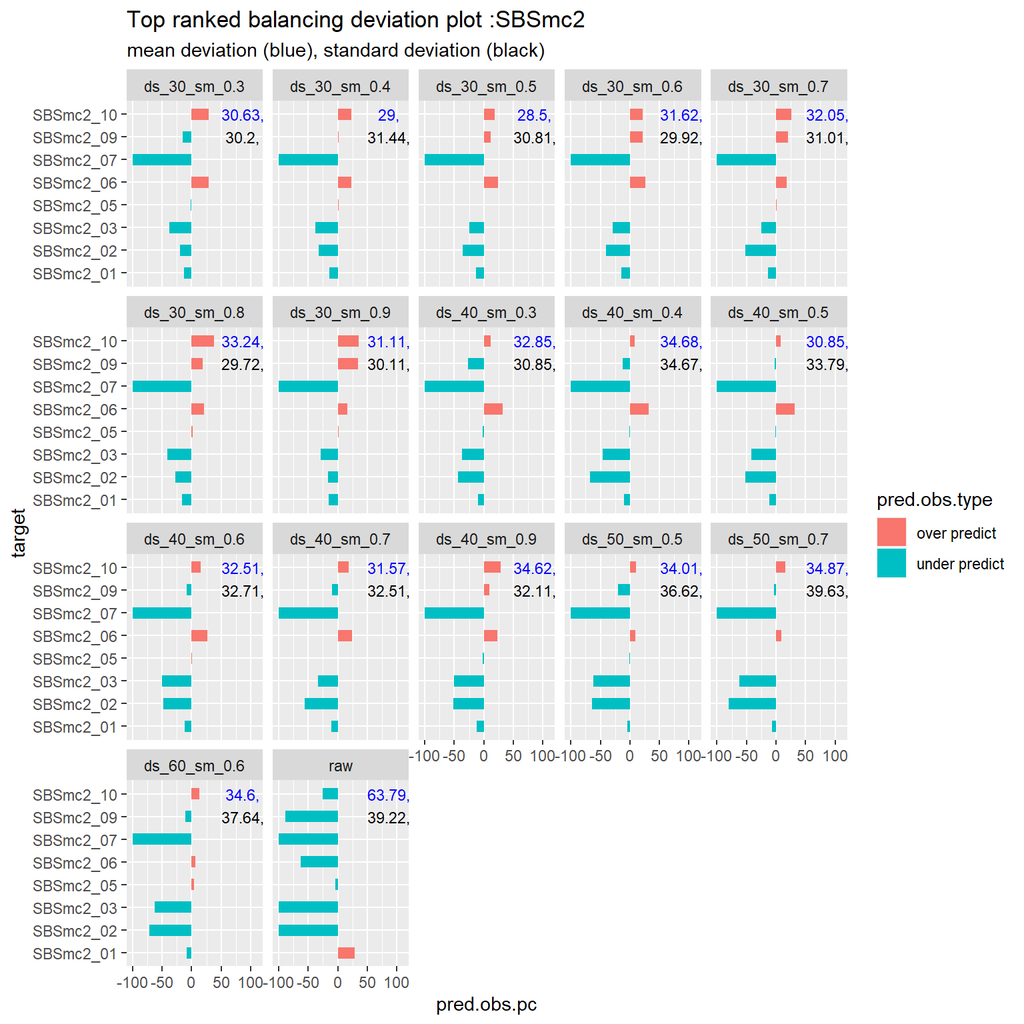

## For further investigation :

Something not quite right about this… - where are we adding the data? Review output and come back - test only adding by unit. - smaller amount of data ? - look at ratio of points with improvement/ decrease improvement. - need to look at both overall + mapunit